# EDF 6938 Lecture 4: Introduction to ggplot2

A.C. Thomas – FSSS

09/21/2015

This will be presented in full R Markdown document form rather than ioslides largely because of the sheer number of graphics and options being presented here. Which is great, because `ggplot2` is extremely thorough with its graphical prowess.

## Install ggplot2

```r
install.packages("ggplot2")  ## which is obvious
install.packages("MASS")     ## which we need for some data.
```

We can use base R graphics to accomplish a lot, but the biggest selling point for `ggplot2` is that it works naturally with data frame structure.

## Simple plots with `qplot`

Let’s load the package and get some data to work with. I’ve got a favorite here:

```r
library(ggplot2)
library(MASS)
head(Cars93)
```

```
##   Manufacturer   Model    Type Min.Price Price Max.Price MPG.city
## 1        Acura Integra   Small      12.9  15.9      18.8       25
## 2        Acura  Legend Midsize      29.2  33.9      38.7       18
## 3         Audi      90 Compact      25.9  29.1      32.3       20
## 4         Audi     100 Midsize      30.8  37.7      44.6       19
## 5          BMW    535i Midsize      23.7  30.0      36.2       22
## 6        Buick Century Midsize      14.2  15.7      17.3       22
##   MPG.highway            AirBags DriveTrain Cylinders EngineSize
## 1          31               None      Front         4        1.8
## 2          25 Driver & Passenger      Front         6        3.2
## 3          26        Driver only      Front         6        2.8
## 4          26 Driver & Passenger      Front         6        2.8
## 5          30        Driver only       Rear         4        3.5
## 6          31        Driver only      Front         4        2.2
##   Horsepower  RPM Rev.per.mile Man.trans.avail Fuel.tank.capacity
```

[output cut: 20 more lines]

There are two modes for plotting: “basic”, using `qplot()`, and “advanced”, using `ggplot()`. Let’s start with the basics.

Some factorial variables, 1-D:

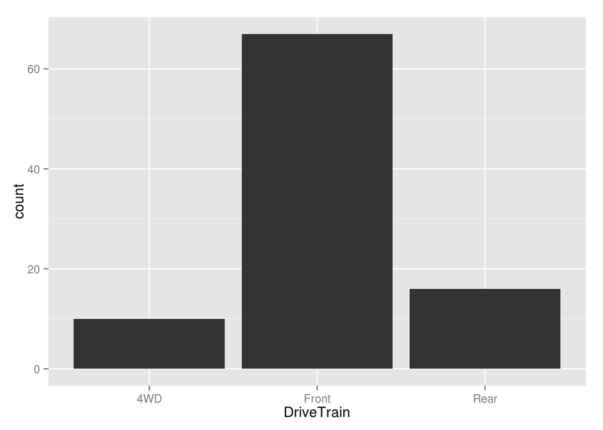

```r
qplot (DriveTrain, data = Cars93)
```

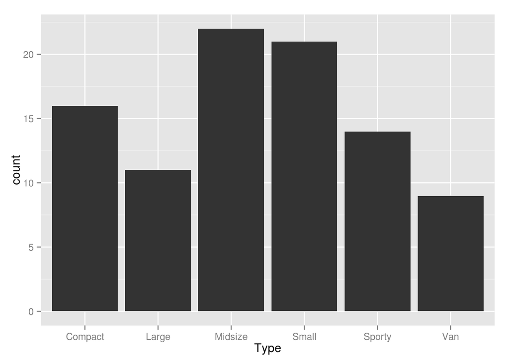

```r
qplot (Type, data = Cars93)
```

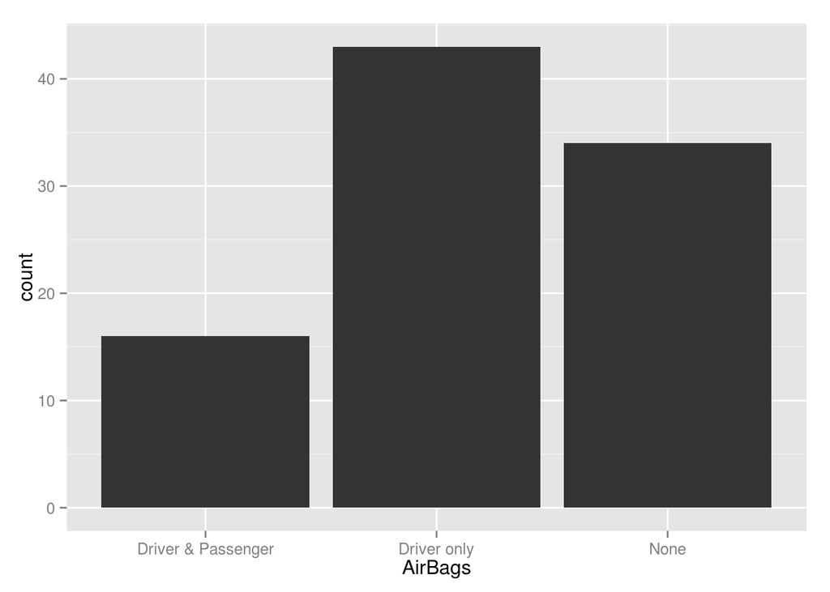

```r
qplot (AirBags, data = Cars93)
```

Defaults to bar charts. What about …

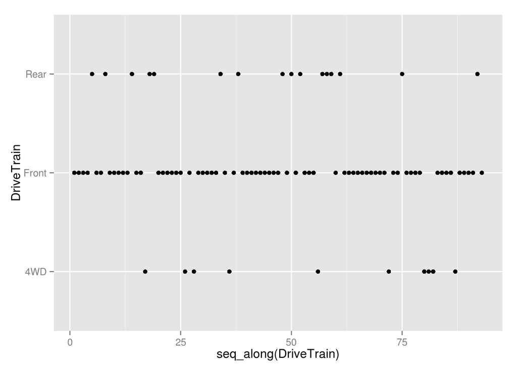

```r
qplot (y = DriveTrain, data = Cars93)
```

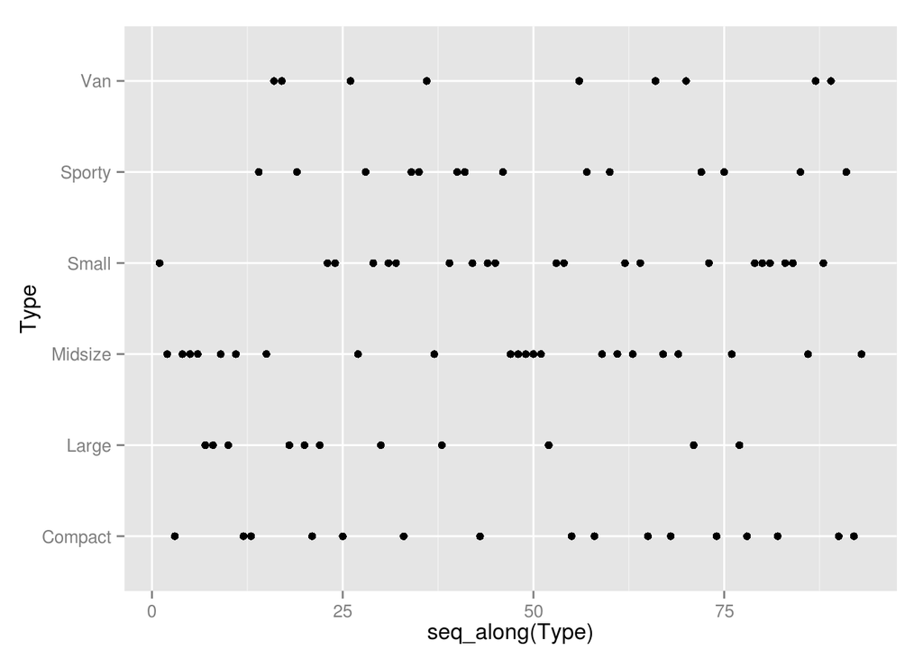

```r
qplot (y = Type, data = Cars93)
```

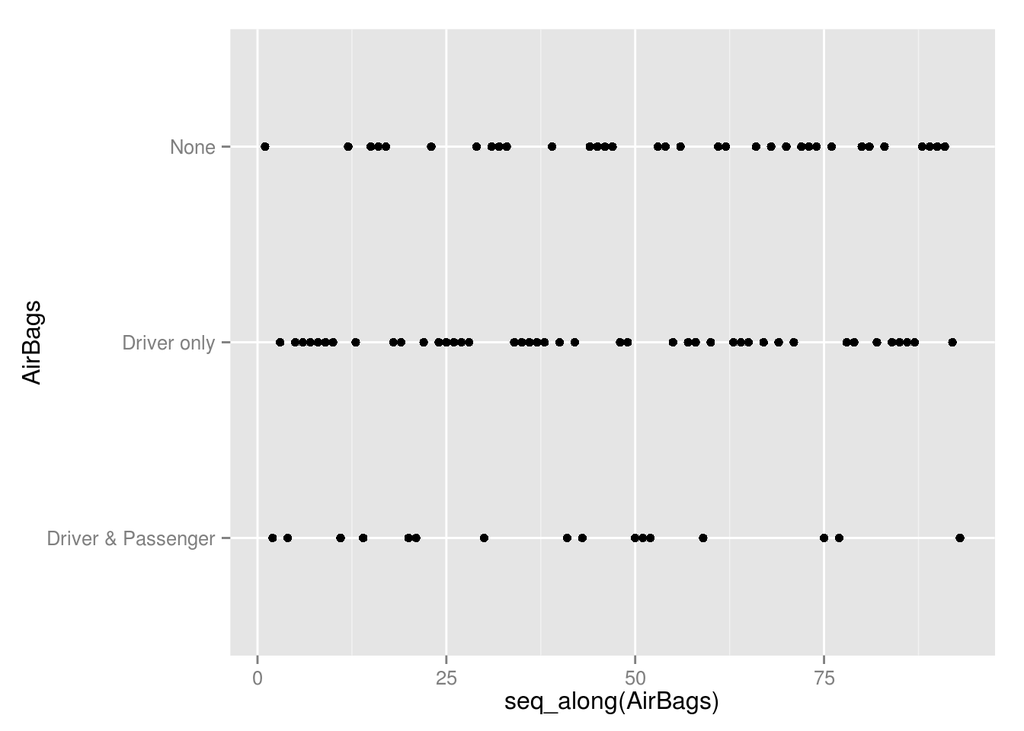

```r
qplot (y = AirBags, data = Cars93)
```

Some numerical variables, 1-D:

```
## stat_bin: binwidth defaulted to range/30. Use 'binwidth = x' to adjust this.
```

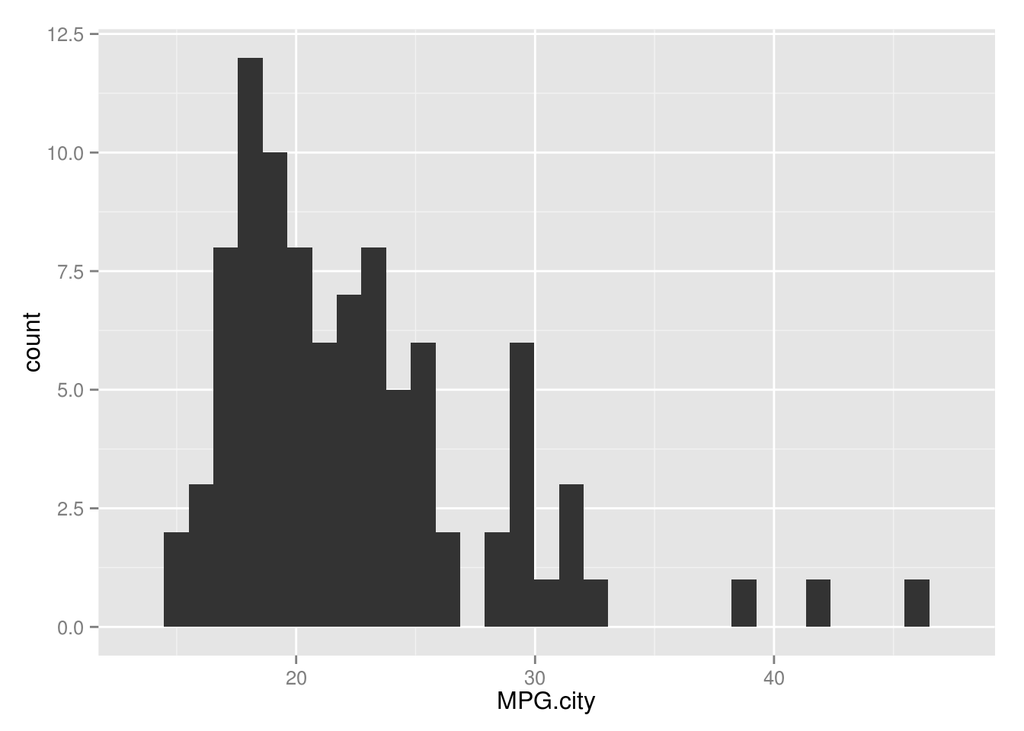

```r
qplot (MPG.city, data = Cars93)     ## numerical
```

```
## stat_bin: binwidth defaulted to range/30. Use 'binwidth = x' to adjust this.
```

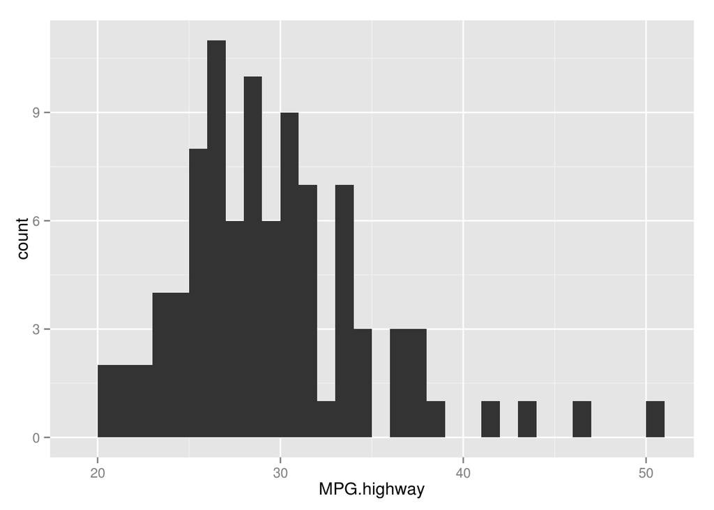

```r
qplot (MPG.highway, data = Cars93)     ## numerical
```

```
## stat_bin: binwidth defaulted to range/30. Use 'binwidth = x' to adjust this.
```

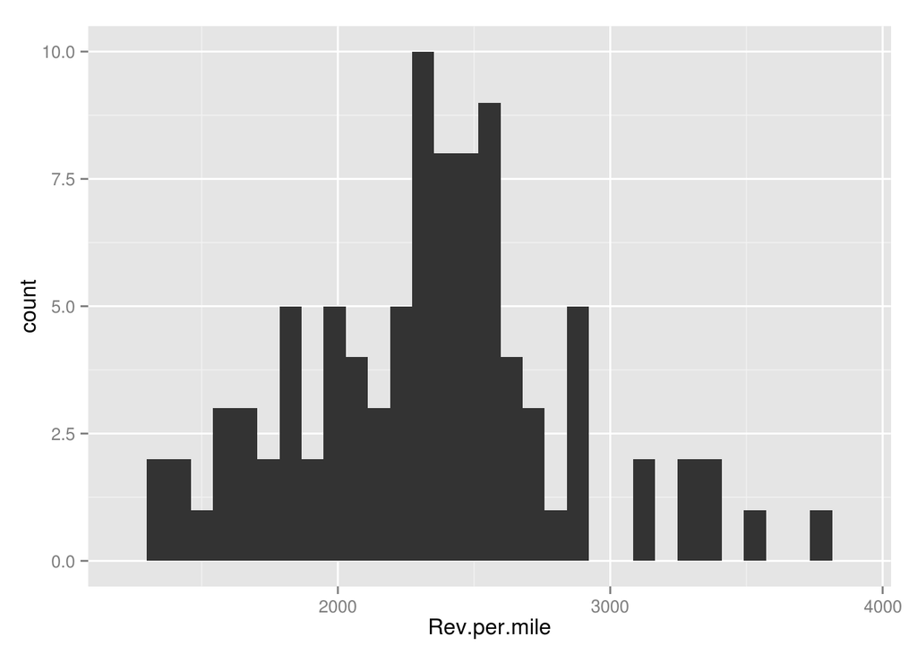

```r
qplot (Rev.per.mile, data = Cars93)     ## numerical
```

Defaults to histograms. Similarly:

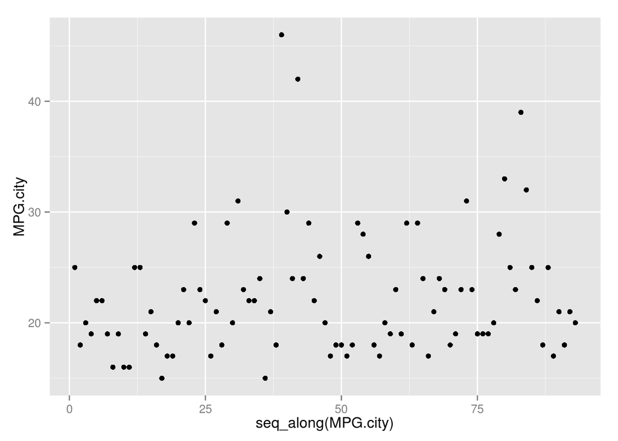

```r
qplot (y=MPG.city, data = Cars93)     ## numerical
```

Let’s add some more features. Two-dimensional plots:

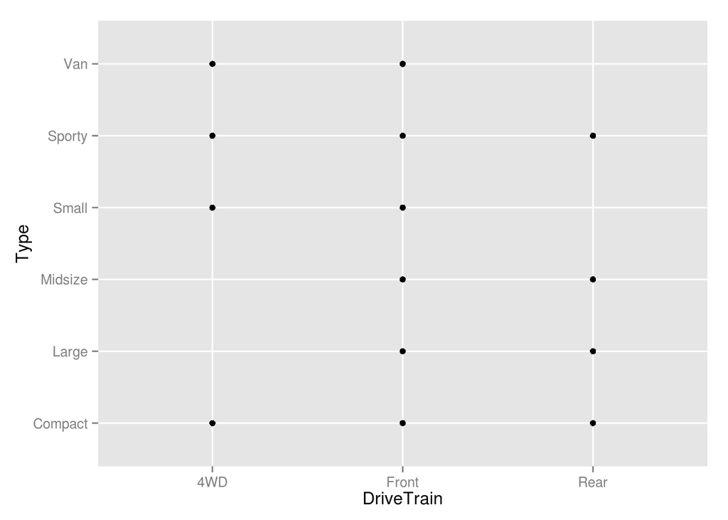

```r
qplot (DriveTrain, Type, data = Cars93)
```

OK, not the mosaic plot we got last time by default. Bummer. Available elsewhere. One feature to add, a sneak peek ahead

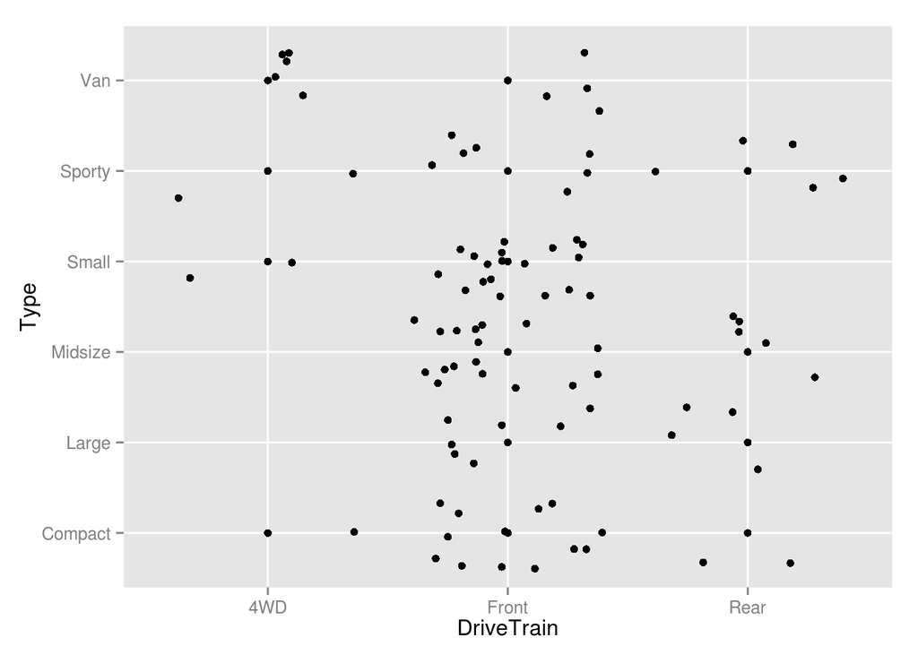

```r
qplot (DriveTrain, Type, data = Cars93) + geom_jitter()
```

How about this?

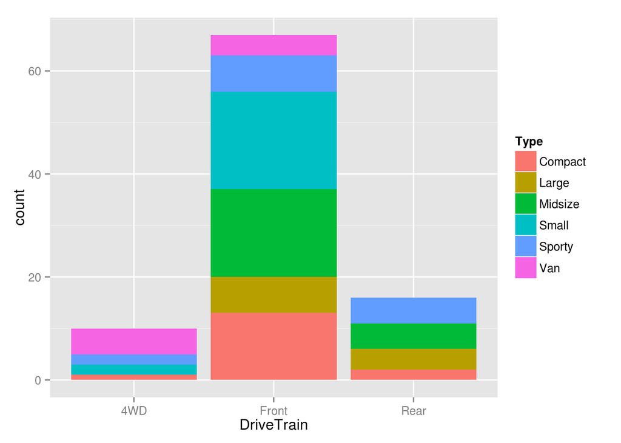

```r
qplot (DriveTrain, data = Cars93, fill = Type)
```

Continuous vs categorical:

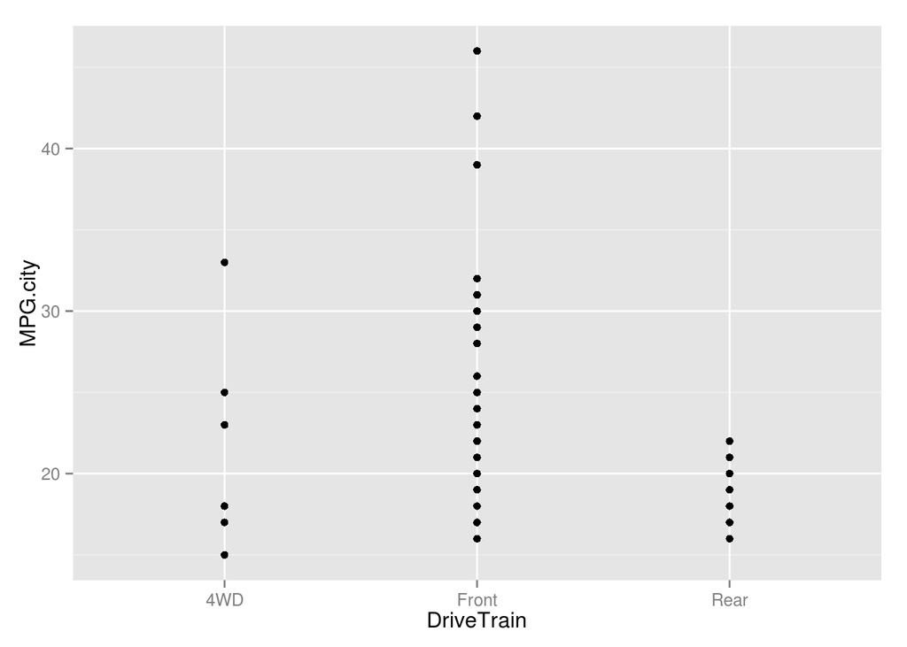

```r
qplot (DriveTrain, MPG.city, data = Cars93)
```

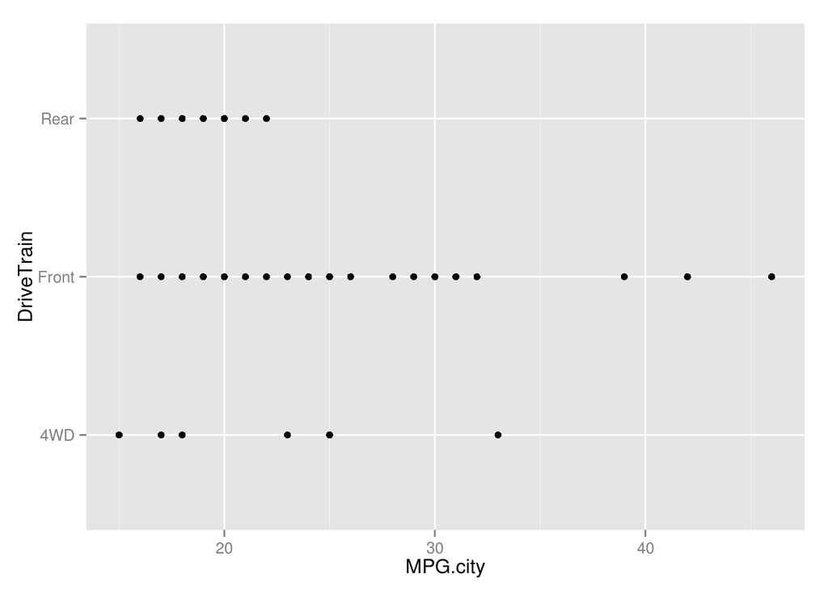

```r
qplot (MPG.city, DriveTrain, data = Cars93)
```

2-D scatterplots: Where we shine! Lots of quick detail with third factors.

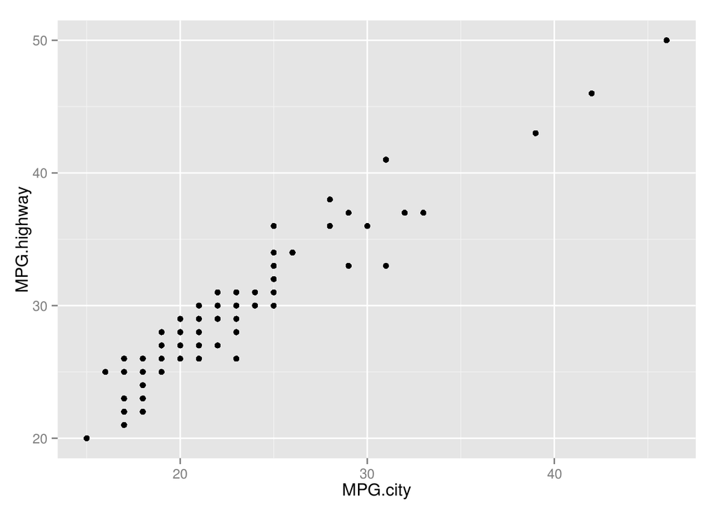

```r
qplot (MPG.city, MPG.highway, data=Cars93)
```

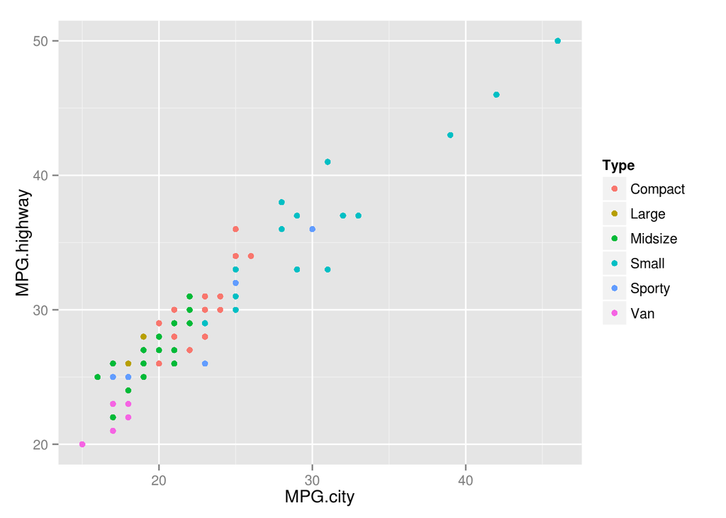

```r
qplot (MPG.city, MPG.highway, data=Cars93, col=Type)
```

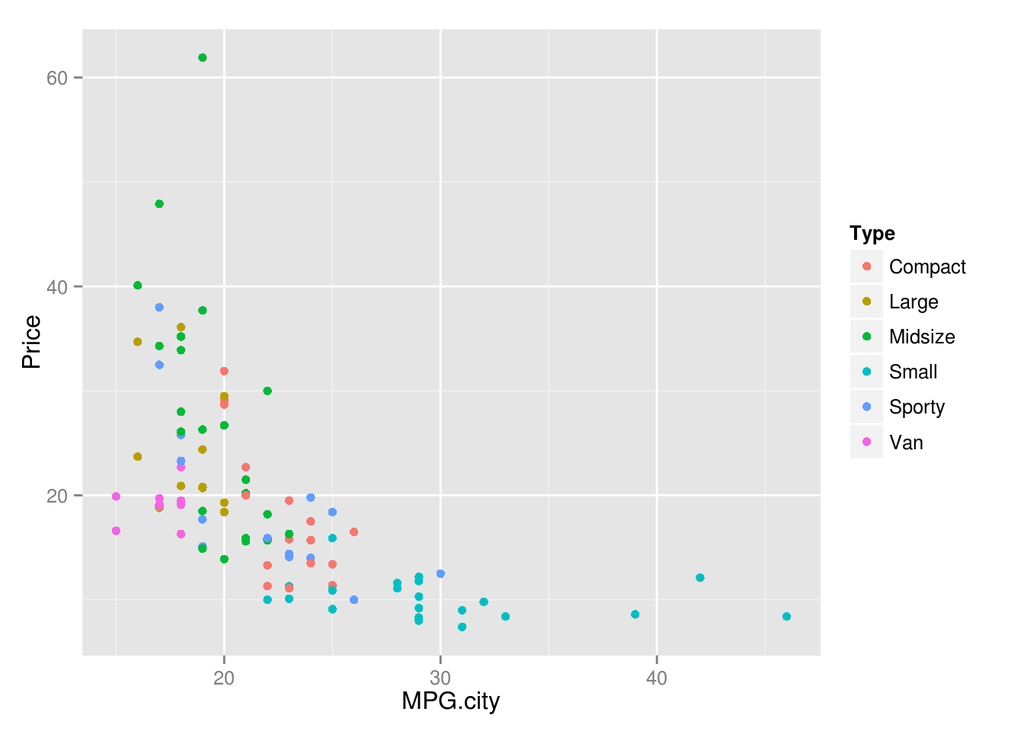

```r
qplot (MPG.city, Price, data=Cars93, col=Type)
```

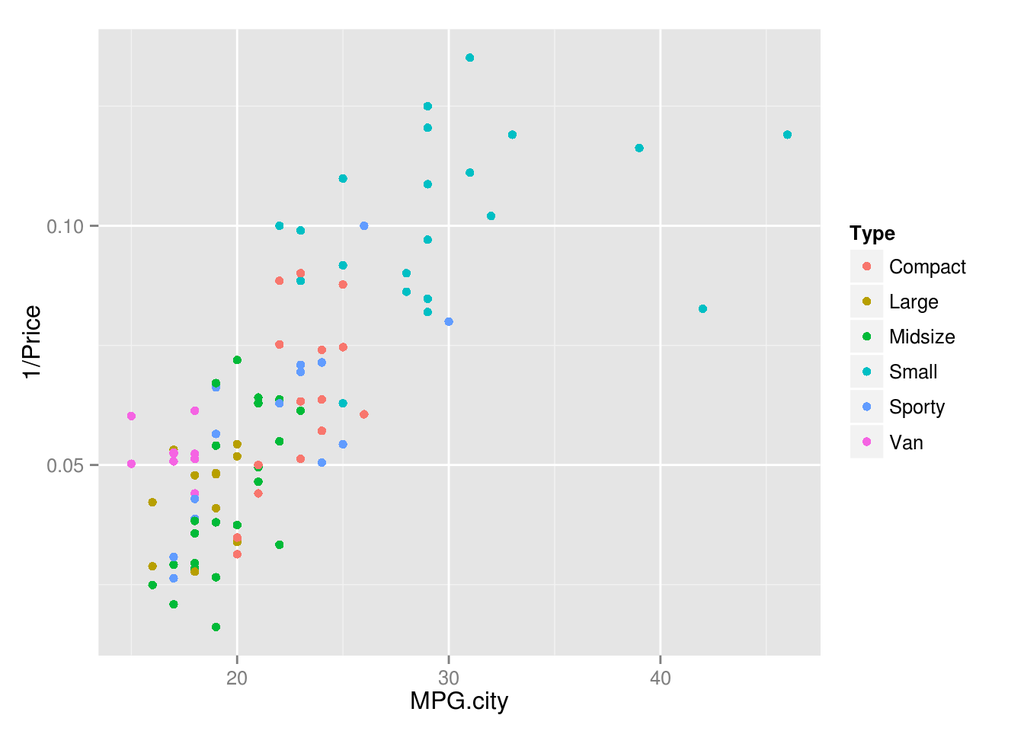

```r
qplot (MPG.city, 1/Price, data=Cars93, col=Type)
```

## Expanding on this: `ggplot` is extensive

The basic premise of `ggplot`:

1. Establish which variables in your data will be the (x,y) pair.
2. Add new features according to “geometries”, which may themselves use other columns in the data.
3. Make everything additive.

Basic notation:

```r
ggplot (Cars93,       ## the data frame
        aes (Type)    ## the "aesthetics"
        )
```

This sets up the basics that follow, but triggers an error when we run it. We have to add at least one layer. For example:

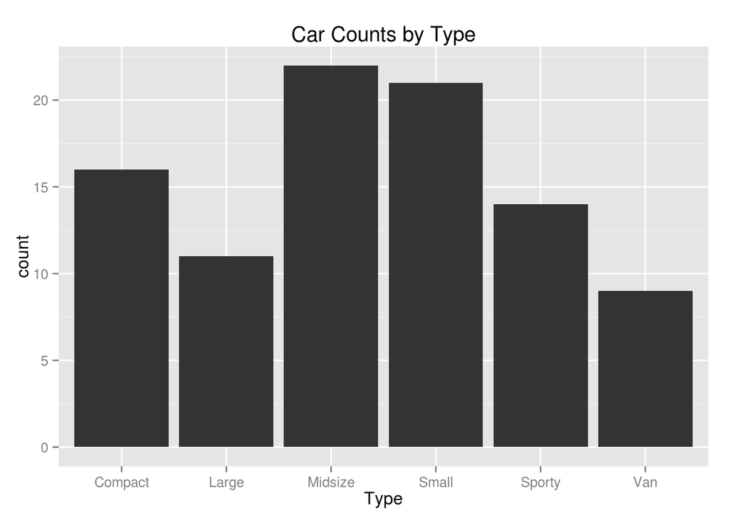

```r
ggplot (Cars93,       ## the data frame
        aes (Type)    ## the "aesthetics"
        ) +
  geom_bar() +
  ggtitle ("Car Counts by Type")
```

How about the coloring we saw before? Add in the “aesthetic” criteria.

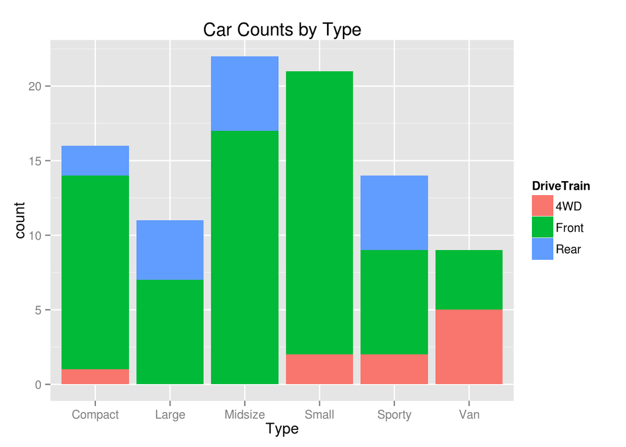

```r
ggplot (Cars93,       ## the data frame
        aes (Type)    ## the "aesthetics"
        ) +
  geom_bar(aes(fill = DriveTrain)) +
  ggtitle ("Car Counts by Type")
```

We’re only going to get so much out of 1-D categorical data, but it’s a good place to introduce the “group_by” of `ggplot`, “facets”.

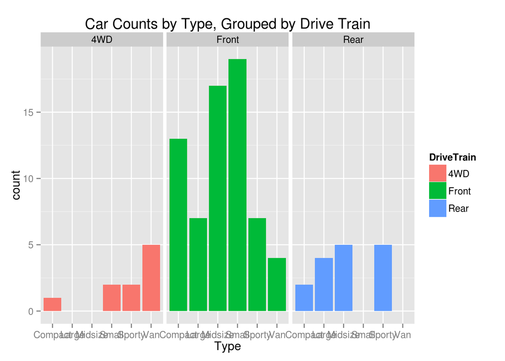

```r
ggplot (Cars93,       ## the data frame
        aes (Type)    ## the "aesthetics"
        ) +
  geom_bar(aes(fill = DriveTrain)) +
  ggtitle ("Car Counts by Type, Grouped by Drive Train") +
  facet_grid (. ~ DriveTrain)
```

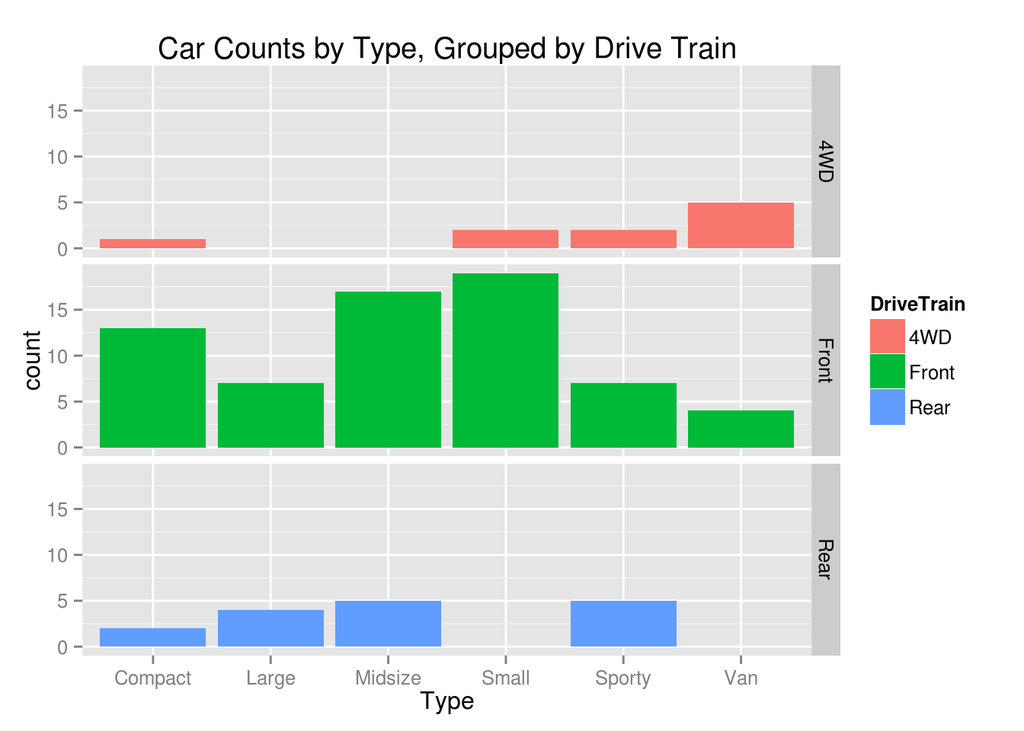

```r
ggplot (Cars93,       ## the data frame
        aes (Type)    ## the "aesthetics"
        ) +
  geom_bar(aes(fill = DriveTrain)) +
  ggtitle ("Car Counts by Type, Grouped by Drive Train") +
  facet_grid (DriveTrain ~ .)
```

Let’s explore a few of the 1-D continuous options:

```
## stat_bindot: binwidth defaulted to range/30. Use 'binwidth = x' to adjust this.
```

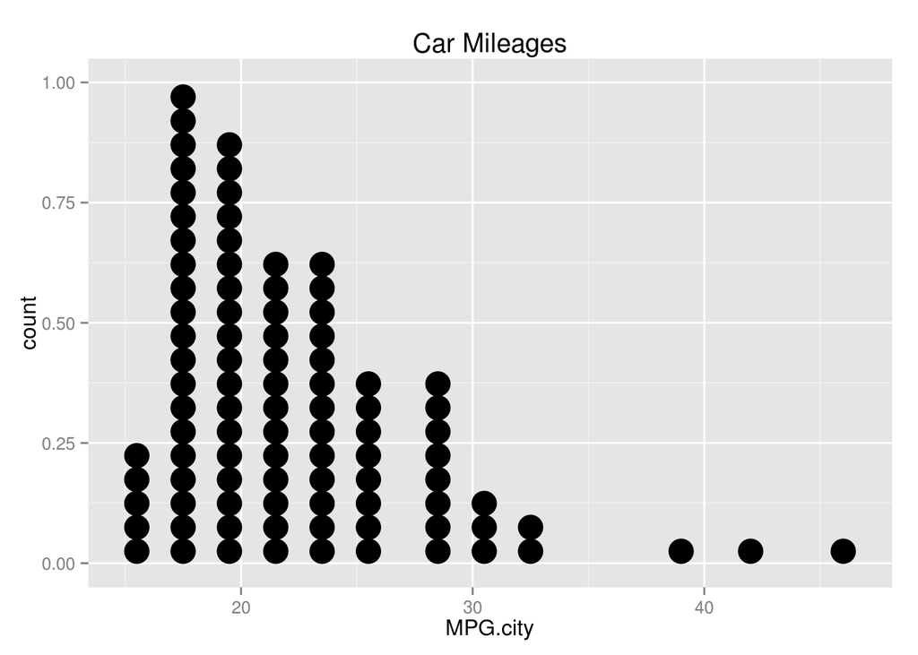

```r
ggplot (Cars93,       ## the data frame
        aes (MPG.city)    ## the "aesthetics"
        ) +
  geom_dotplot() +
  ggtitle ("Car Mileages")
```

Unexpected side-effects.

```
## stat_bindot: binwidth defaulted to range/30. Use 'binwidth = x' to adjust this.
```

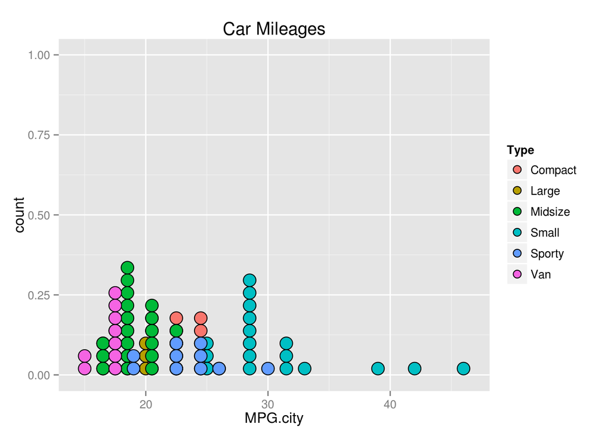

```r
ggplot (Cars93,       ## the data frame
        aes (MPG.city)    ## the "aesthetics"
        ) +
  geom_dotplot(aes(fill = Type)) +
  ggtitle ("Car Mileages")
```

```
## stat_bin: binwidth defaulted to range/30. Use 'binwidth = x' to adjust this.
```

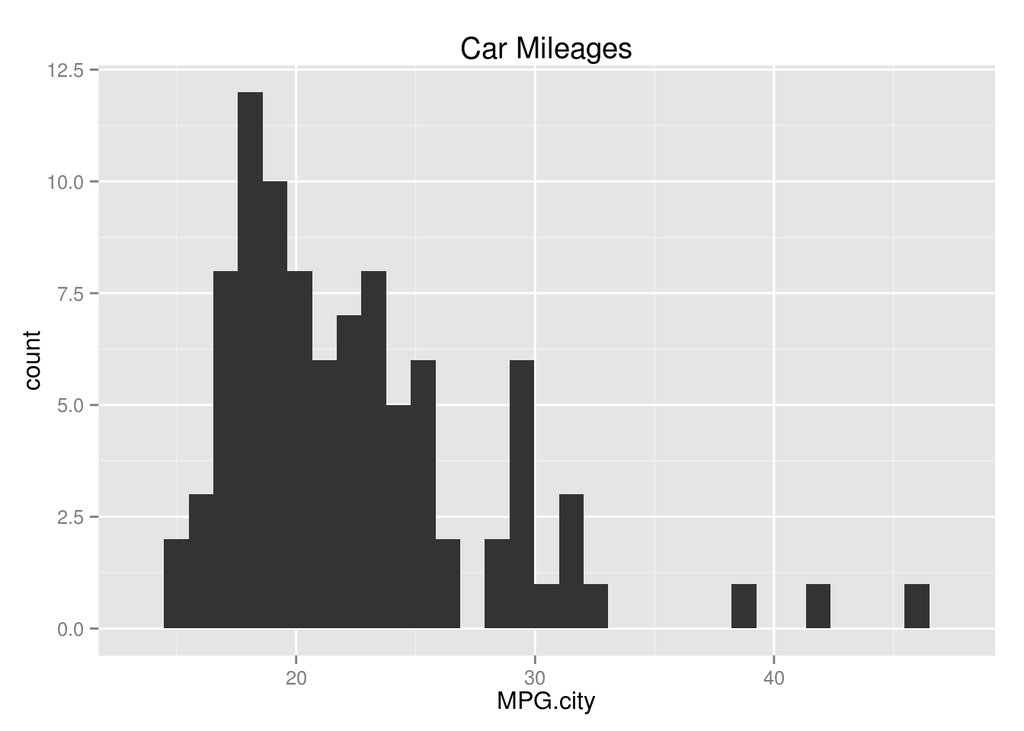

```r
ggplot (Cars93,       ## the data frame
        aes (MPG.city)    ## the "aesthetics"
        ) +
  geom_histogram() +
  ggtitle ("Car Mileages")
```

```
## stat_bin: binwidth defaulted to range/30. Use 'binwidth = x' to adjust this.
```

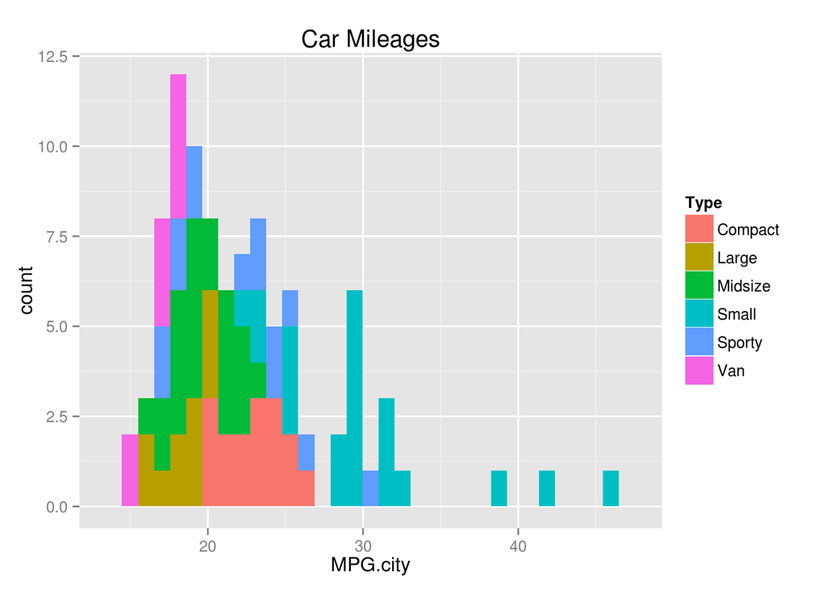

```r
ggplot (Cars93,       ## the data frame
        aes (MPG.city)    ## the "aesthetics"
        ) +
  geom_histogram(aes(fill = Type)) +
  ggtitle ("Car Mileages")
```

Overlap can be an issue here:

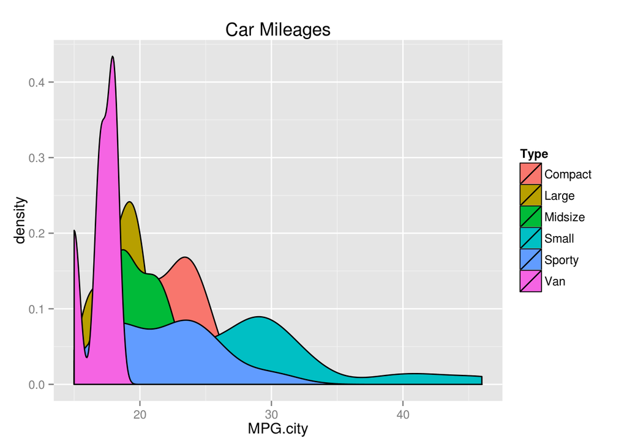

```r
ggplot (Cars93,       ## the data frame
        aes (MPG.city)    ## the "aesthetics"
        ) +
  geom_density(aes(fill = Type)) +
  ggtitle ("Car Mileages")
```

Does splitting by group help our view here? Note the mild statistical distortion: all the frequencies by group add to 1 even though the baseline groups are of unequal size.

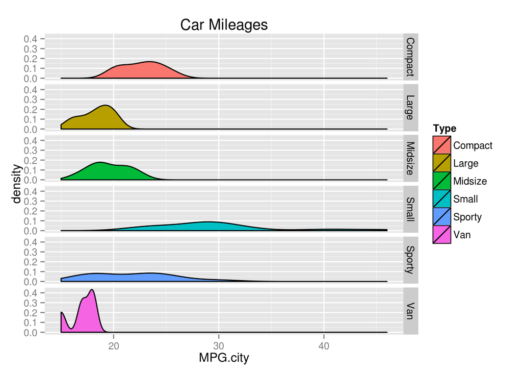

```r
ggplot (Cars93,       ## the data frame
        aes (MPG.city)    ## the "aesthetics"
        ) +
  geom_density(aes(fill = Type)) +
  ggtitle ("Car Mileages") +
  facet_grid (Type ~ .)
```